# _00_by_region

Julian Kleindiek

7/23/2020

### Step 1. Read in data

```r
# set working directory
setwd(path)

# read in flight data
df = fread(file.path(filename))

# save df as tibble
df = as_tibble(df)

# print available columns
names(df)
```

```
##  [1] "V1"                            "fg_apt"
##  [3] "usg_apt"                       "data_dte"
##  [5] "year"                          "month"
##  [7] "usg_apt_id"                    "usg_wac"
##  [9] "fg_apt_id"                     "fg_wac"
## [11] "airlineid"                     "carrier"
## [13] "carriergroup"                  "type"
## [15] "scheduled"                     "charter"
## [17] "total"                         "in_flights"
## [19] "usg_icao"                      "usg_airport"
## [21] "usg_city"                      "usg_country"
## [23] "usg_latitude_decimal_degrees"  "usg_longitude_decimal_degrees"
## [25] "usg_in_iata"                   "fg_icao"
## [27] "fg_airport"                    "fg_city"
## [29] "fg_country"                    "fg_latitude_decimal_degrees"
## [31] "fg_longitude_decimal_degrees"  "fg_in_iata"
```

```r
# head
head(df)
```

```
## # A tibble: 6 x 32
##      V1 fg_apt usg_apt data_dte  year month usg_apt_id usg_wac fg_apt_id
##   <int> <chr>  <chr>   <chr>    <int> <int>      <int>   <int>     <int>
## 1     1 AAL    PHL     8/1/1993  1993     8      14100      23     10125
## 2     2 AAL    RSW     8/1/2011  2011     8      14635      33     10125
## 3     3 AAL    RSW     6/1/2011  2011     6      14635      33     10125
## 4     4 AAL    RSW     7/1/2011  2011     7      14635      33     10125
## 5     5 AAO    PNE     6/1/2014  2014     6      14182      23     10128
## 6     6 AAO    TEB     9/1/2018  2018     9      15167      21     10128
## # … with 23 more variables: fg_wac <int>, airlineid <int>, carrier <chr>,
## #   carriergroup <int>, type <chr>, scheduled <chr>, charter <chr>,
## #   total <chr>, in_flights <int>, usg_icao <chr>, usg_airport <chr>,
## #   usg_city <chr>, usg_country <chr>, usg_latitude_decimal_degrees <dbl>,
## #   usg_longitude_decimal_degrees <dbl>, usg_in_iata <int>, fg_icao <chr>,
## #   fg_airport <chr>, fg_city <chr>, fg_country <chr>,
## #   fg_latitude_decimal_degrees <dbl>, fg_longitude_decimal_degrees <dbl>,
## #   fg_in_iata <int>
```

### Step 2. Data cleaning

```r
# to numeric
df$total = as.numeric(gsub(",", "", df$total))
df$scheduled = as.numeric(gsub(",", "", df$scheduled))
```

### Step 3. Data visualization

```r
# define regions
south_europe = c("PORTUGAL", "SPAIN", "MALTA", "CYPRUS", "FRANCE", "ITALY", "CROATIA", "GREECE")
southeast_asia = c("INDONESIA", "THAILAND", "MALAYSIA", "PHILIPPINES", "CAMBODIA") # "VIETNAM", "SINGAPUR", "LAOS"
south_america = c("BRAZIL", "ARGENTINA", "COLOMBIA", "PERU", "CHILE", "ECUADOR", "BOLIVIA")
oceania = c("AUSTRALIA", "NEW ZEALAND")
```

```r
# filter dat by given regions
df_south_europe = df %>% filter(fg_country %in% south_europe)
df_southeast_asia = df %>% filter(fg_country %in% southeast_asia)
df_south_america = df %>% filter(fg_country %in% south_america)
df_oceania = df %>% filter(fg_country %in% oceania)
```

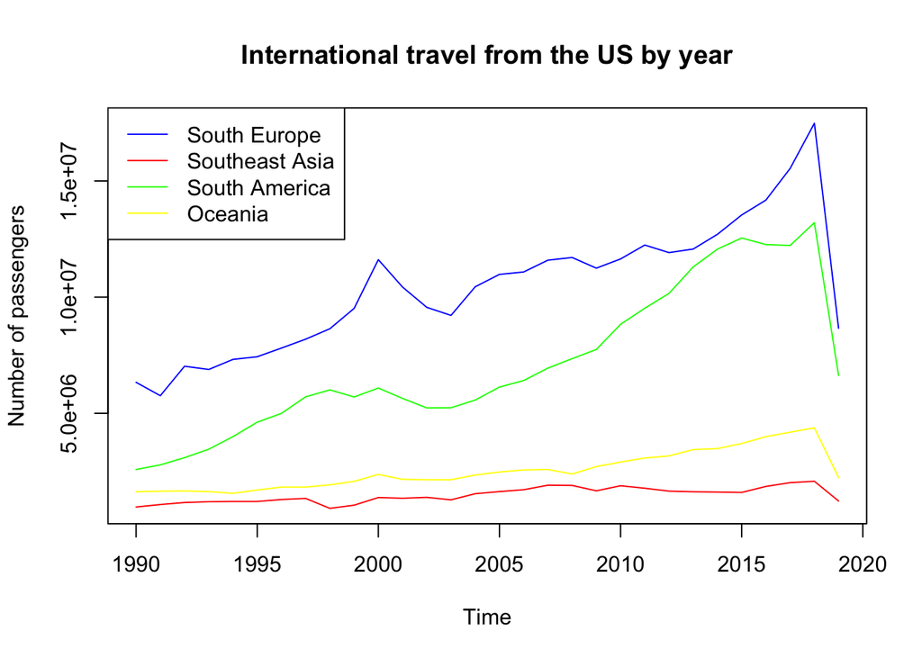

```r
# aggregate by year
df_south_europe_y = aggregate(df_south_europe$total, by=list(cat1=df_south_europe$year), FUN=sum)
df_southeast_asia_y = aggregate(df_southeast_asia$total, by=list(cat1=df_southeast_asia$year), FUN=sum)
df_south_america_y= aggregate(df_south_america$total, by=list(cat1=df_south_america$year), FUN=sum)
df_oceania_y = aggregate(df_oceania$total, by=list(cat1=df_oceania$year), FUN=sum)

# create time series object
south_europe_ts_y = ts(df_south_europe_y$x, start=1990, end=2019, frequency = 1)
southeast_asia_ts_y = ts(df_southeast_asia_y$x, start=1990, end=2019, frequency = 1)
south_america_ts_y = ts(df_south_america_y$x, start=1990, end=2019, frequency = 1)
oceania_ts_y = ts(df_oceania_y$x, start=1990, end=2019, frequency = 1)

# plot
ts.plot(south_europe_ts_y, southeast_asia_ts_y, south_america_ts_y, oceania_ts_y,
        ylab="Number of passengers", xlab="Time", col=c("blue", "red", "green", "yellow"),
        main="International travel from the US by year")
legend("topleft", lty=c(1,1,1,1), col=c("blue", "red", "green", "yellow"),
       legend=c("South Europe", "Southeast Asia", "South America", "Oceania"))
```

- Note that 2019 data is not complete

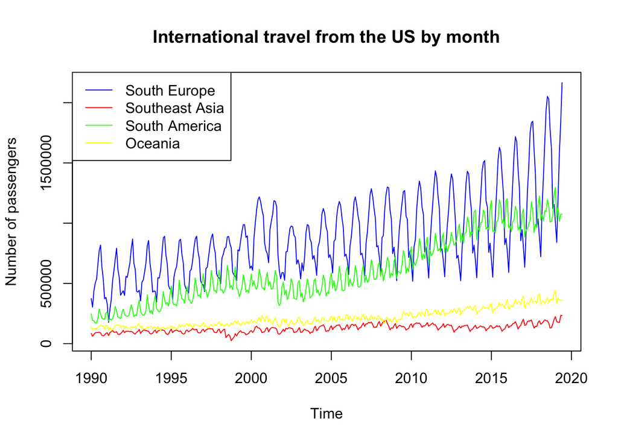

```r
# aggregate by month
df_south_europe_m = aggregate(df_south_europe$total, by=list(cat1=df_south_europe$year,
                                                             cat2=df_south_europe$month), FUN=sum)
df_southeast_asia_m = aggregate(df_southeast_asia$total, by=list(cat1=df_southeast_asia$year,
                                                             cat2=df_southeast_asia$month), FUN=sum)
df_south_america_m = aggregate(df_south_america$total, by=list(cat1=df_south_america$year,
                                                             cat2=df_south_america$month), FUN=sum)
df_oceania_m = aggregate(df_oceania$total, by=list(cat1=df_oceania$year,
                                                             cat2=df_oceania$month), FUN=sum)

# create time series object
south_europe_ts_m = ts(df_south_europe_m[order(df_south_europe_m$cat1),]$x, frequency = 12, start=c(1990,1))
southeast_asia_ts_m = ts(df_southeast_asia_m[order(df_southeast_asia_m$cat1),]$x, frequency = 12, start=c(1990,1))
south_america_ts_m = ts(df_south_america_m[order(df_south_america_m$cat1),]$x, frequency = 12, start=c(1990,1))
oceania_ts_m = ts(df_oceania_m[order(df_oceania_m$cat1),]$x, frequency = 12, start=c(1990,1))

# plot
ts.plot(south_europe_ts_m, southeast_asia_ts_m, south_america_ts_m, oceania_ts_m,
        ylab="Number of passengers", xlab="Time", col=c("blue", "red", "green", "yellow"),
        main="International travel from the US by month")
legend("topleft", lty=c(1,1,1,1), col=c("blue", "red", "green", "yellow"),
       legend=c("South Europe", "Southeast Asia", "South America", "Oceania"))
```

### Step 4. Data modeling

#### South Europe Monthly

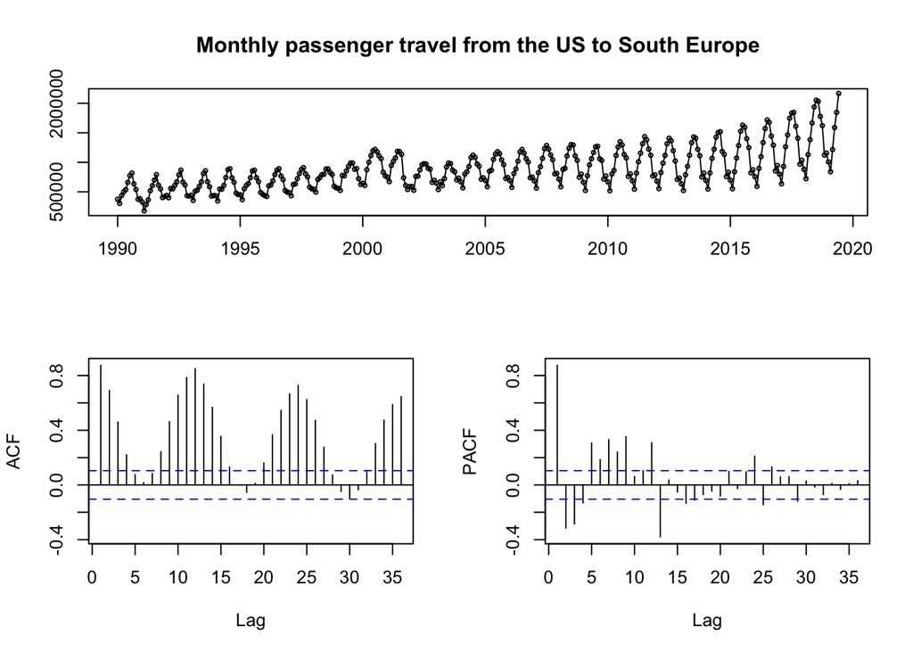

```r
# plot the data
tsdisplay(south_europe_ts_m, main="Monthly passenger travel from the US to South Europe")
```

- The data is non-stationary having a positive trend  
- Further, it follows a seasonal pattern with a non-constant variance over time

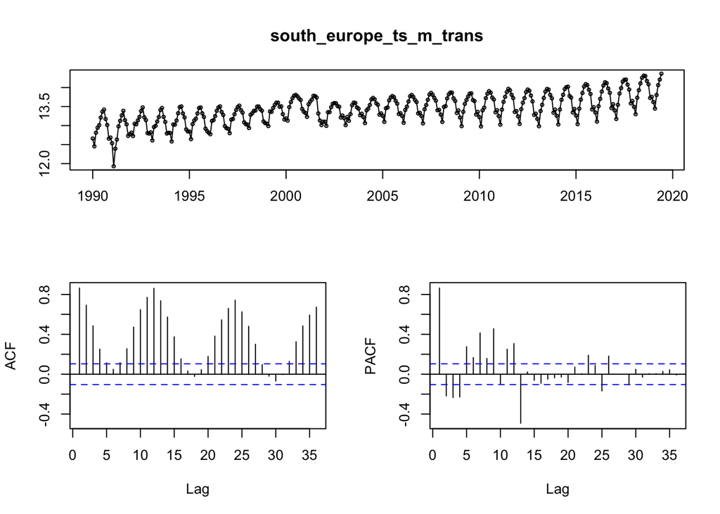

```r
# plot with box-cox transformation
lambda = BoxCox.lambda(south_europe_ts_m)
south_europe_ts_m_trans = BoxCox(south_europe_ts_m, lambda=lambda)
tsdisplay(south_europe_ts_m_trans)
```

- The Box-Cox transformation leads to a more constant variance over time

```r
# test for stationarity of training data with KPSS test
kpss.test(south_europe_ts_m, null="Level")
```

```
##
##  KPSS Test for Level Stationarity
##
## data:  south_europe_ts_m
## KPSS Level = 3.8023, Truncation lag parameter = 5, p-value = 0.01
```

- The null hypothesis for the KPSS test is that the data is stationary  
- Large p-values are indicative of stationarity and small p-values suggest non-stationarity  
- For this data, the p-value is 0.01 and hence the data is non-stationary at a 5% significance level

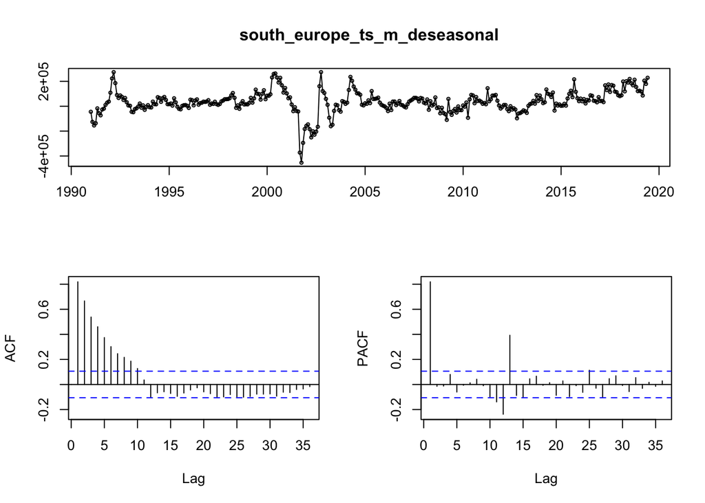

```r
# deseasonalize data
south_europe_ts_m_deseasonal = diff(south_europe_ts_m, lag=12)

# plot results
tsdisplay(south_europe_ts_m_deseasonal)
```

- After deseasonalizing the data, we can observe no seasonality in the data anymore  
- In the PACF, there is a cutoff at lag 1 and at lag 12 allowing to draw the conclusion that p and P could both be 1  
- The ACF is now decaying, which it wasn’t prior to the seasonal differencing and which is a good sign

```r
# select test and training data
train = window(south_europe_ts_m, c(2008,1), c(2018,6))
test = window(south_europe_ts_m, c(2018,7))
```

```r
# fit auto.arima() model
model_1 = auto.arima(train, stationary=FALSE, seasonal=TRUE)

# summary
summary(model_1)
```

```
## Series: train
## ARIMA(1,1,0)(1,1,0)[12]
##
## Coefficients:
##           ar1     sar1
##       -0.3701  -0.4458
## s.e.   0.0897   0.0921
##
## sigma^2 estimated as 1.752e+09:  log likelihood=-1363.28
## AIC=2732.56   AICc=2732.78   BIC=2740.74
##
## Training set error measures:
##                    ME     RMSE      MAE       MPE     MAPE      MASE
## Training set 3670.732 39287.08 27622.72 0.1042226 2.614559 0.4446678
##                     ACF1
## Training set -0.00536183
```

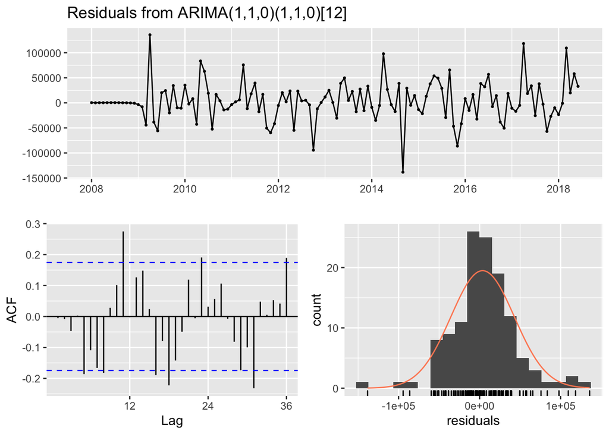

```
##
##  Ljung-Box test
##
## data:  Residuals from ARIMA(1,1,0)(1,1,0)[12]
## Q* = 57.519, df = 22, p-value = 5.163e-05
##
## Model df: 2.   Total lags used: 24
```

```r
# investigate residuals
checkresiduals(model_1)
```

#### South America Monthly

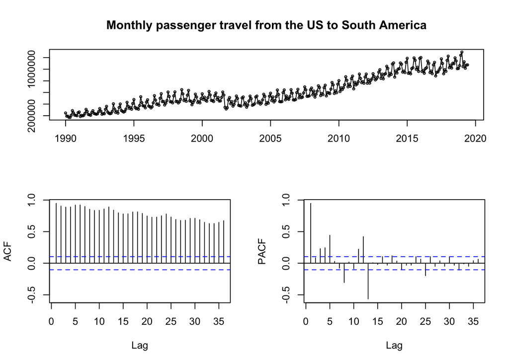

```r
# plot the data
tsdisplay(south_america_ts_m, main="Monthly passenger travel from the US to South America")
```

- The data is non-stationary having a positive trend  
- Further, it follows a seasonal pattern with a non-constant variance over time

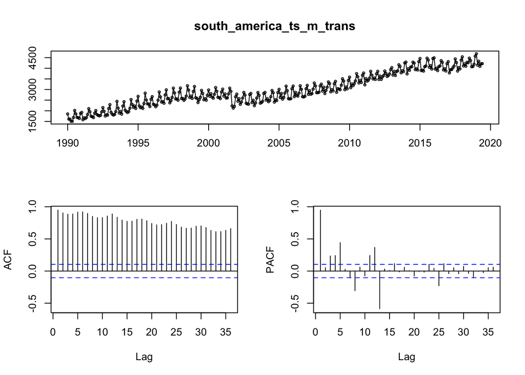

```r
# plot with box-cox transformation
lambda_2 = BoxCox.lambda(south_america_ts_m)
south_america_ts_m_trans = BoxCox(south_america_ts_m, lambda=lambda_2)
tsdisplay(south_america_ts_m_trans)
```

- The Box-Cox transformation leads to a more constant variance over time

```r
# test for stationarity of training data with KPSS test
kpss.test(south_america_ts_m, null="Level")
```

```
##
##  KPSS Test for Level Stationarity
##
## data:  south_america_ts_m
## KPSS Level = 5.4478, Truncation lag parameter = 5, p-value = 0.01
```

- The null hypothesis for the KPSS test is that the data is stationary  
- Large p-values are indicative of stationarity and small p-values suggest non-stationarity  
- For this data, the p-value is 0.01 and hence the data is non-stationary at a 5% significance level

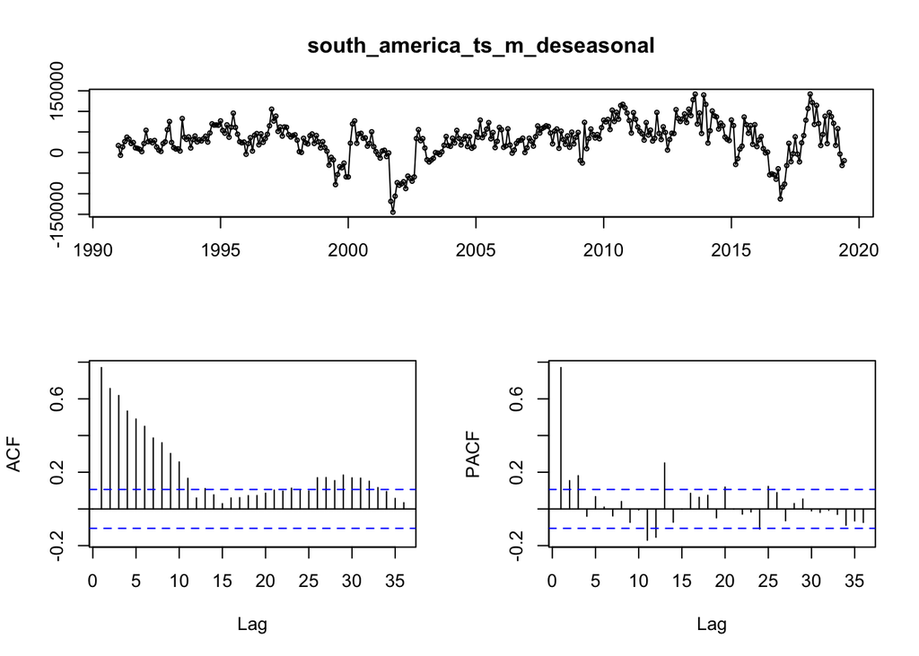

```r
# deseasonalize data
south_america_ts_m_deseasonal = diff(south_america_ts_m, lag=12)

# plot results
tsdisplay(south_america_ts_m_deseasonal)
```

- After deseasonalizing the data, we can observe no seasonality in the data anymore  
- In the PACF, there is a cutoff at lag 1 and at lag 12 allowing to draw the conclusion that p and P could both be 1  
- The ACF is now decaying, which it wasn’t prior to the seasonal differencing and which is a good sign

```r
# select test and training data
train_2 = window(south_america_ts_m, c(2008,1), c(2018,6))
test_2 = window(south_america_ts_m, c(2018,7))
```

```r
# fit auto.arima() model
model_2 = auto.arima(train_2, stationary=FALSE, seasonal=TRUE)

# summary
summary(model_2)
```

```
## Series: train_2
## ARIMA(0,1,2)(1,1,1)[12]
##
## Coefficients:
##           ma1      ma2    sar1     sma1
##       -0.3821  -0.1604  0.2612  -0.7862
## s.e.   0.1016   0.1026  0.1707   0.1547
##
## sigma^2 estimated as 874232613:  log likelihood=-1325.13
## AIC=2660.26   AICc=2660.82   BIC=2673.89
##
## Training set error measures:
##                    ME     RMSE      MAE         MPE     MAPE      MASE
## Training set 136.6011 27500.56 20780.57 -0.04038064 2.341408 0.3426342
##                      ACF1
## Training set -0.007517931
```

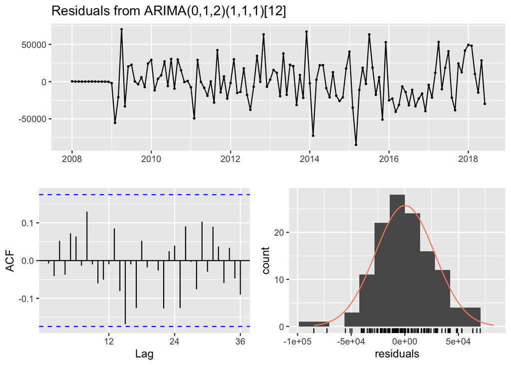

```
##
##  Ljung-Box test
##
## data:  Residuals from ARIMA(0,1,2)(1,1,1)[12]
## Q* = 17.089, df = 20, p-value = 0.6472
##
## Model df: 4.   Total lags used: 24
```

```r
# investigate residuals
checkresiduals(model_2)
```

### Step 5. Forecasting

#### South Europe Monthly

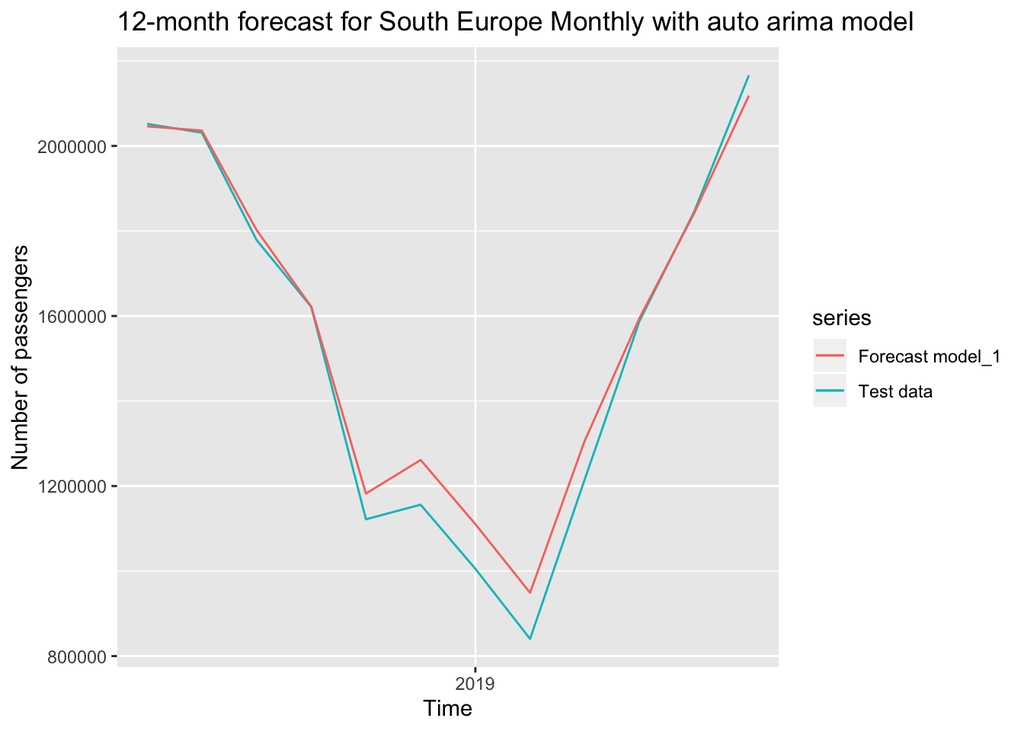

```r
# forecast the year 1980
h = 12
fc_1 = forecast(model_1, h=h)

# plot test data and forecasts of both models
autoplot(test, xlab = "Time", ylab = "Number of passengers",
         main="12-month forecast for South Europe Monthly with auto arima model", series="Test data") +
  autolayer(fc_1$mean, series="Forecast model_1")
```

```r
# accuracy of model_1
accuracy(fc_1, test)
```

```
##                      ME     RMSE      MAE        MPE     MAPE      MASE
## Training set   3670.732 39287.08 27622.72  0.1042226 2.614559 0.4446678
## Test set     -37358.885 63735.56 46940.82 -3.7203612 4.170248 0.7556487
##                     ACF1 Theil's U
## Training set -0.00536183        NA
## Test set      0.60684533 0.2882723
```

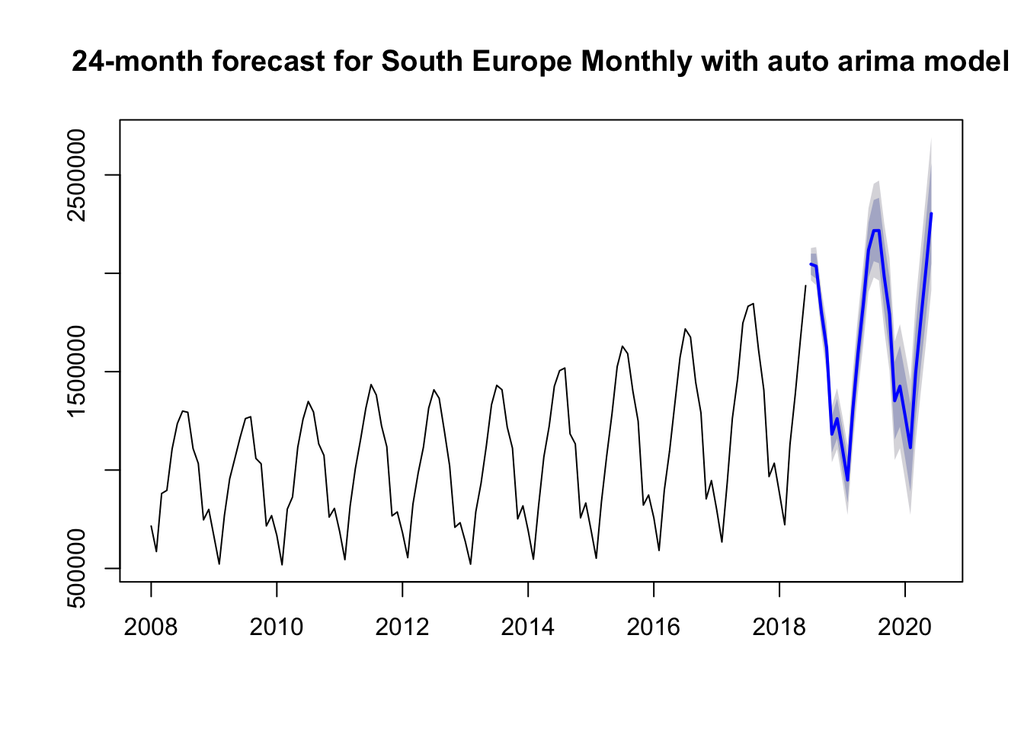

```r
# forecast into the future
fc_2 = forecast(model_1, h=24, level=c(80, 95))

# plot the forecast
plot(fc_2, main="24-month forecast for South Europe Monthly with auto arima model")
```

#### South America Monthly

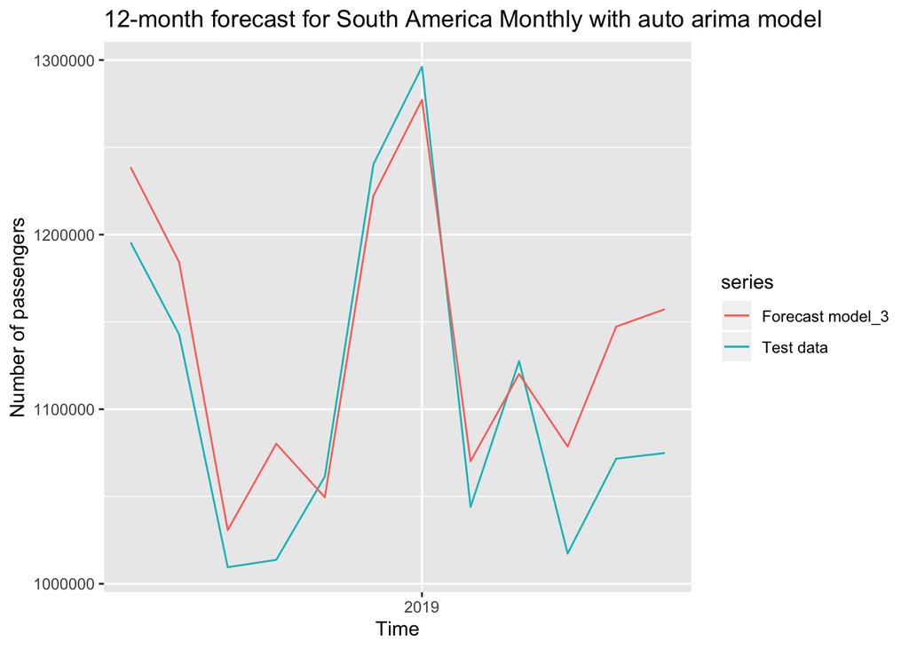

```r
# forecast the year 1980
h = 12
fc_3 = forecast(model_2, h=h)

# plot test data and forecasts of both models
autoplot(test_2, xlab = "Time", ylab = "Number of passengers",
         main="12-month forecast for South America Monthly with auto arima model", series="Test data") +
  autolayer(fc_3$mean, series="Forecast model_3")
```

```r
# accuracy of model_1
accuracy(fc_3, test)
```

```
##                       ME      RMSE       MAE         MPE      MAPE
## Training set    136.6011  27500.56  20780.57 -0.04038064  2.341408
## Test set     397238.2602 587534.44 491837.06 18.95778424 28.971690
##                   MASE         ACF1 Theil's U
## Training set 0.3426342 -0.007517931        NA
## Test set     8.1095085  0.712341701  1.524712
```

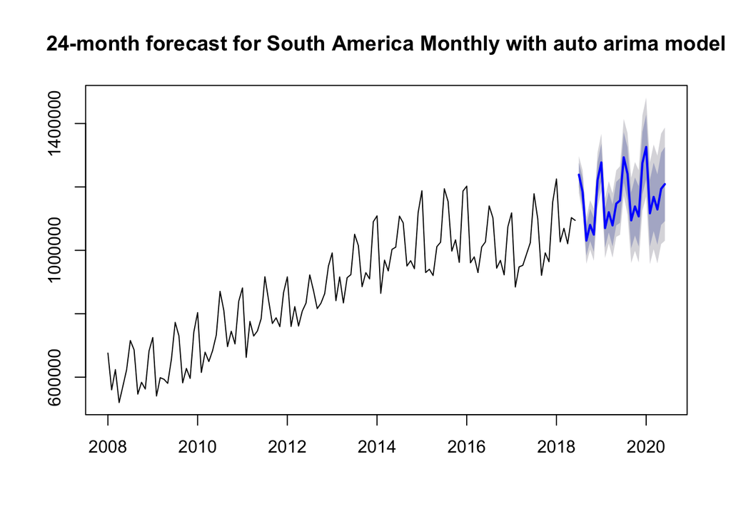

```r
# forecast into the future
fc_4 = forecast(model_2, h=24, level=c(80, 95))

# plot the forecast
plot(fc_4, main="24-month forecast for South America Monthly with auto arima model")
```

### Open Questions:

- I still have a pattern in my residuals because of a second/offset seasonality; how can I integrate that into my model?